# Lead Scoring case study

Submission by Sharheda Raghavan ; Balaji Raman K

```python
import pandas as pd
import numpy as np
import matplotlib.pyplot as plt
import seaborn as sns


# visulaisation
from matplotlib.pyplot import xticks
%matplotlib inline
```

```python
import warnings
warnings.filterwarnings('ignore')
```

### Step1 Importing Data and Data Observation

```python
score_df=pd.read_csv("Leads.csv")
score_df.head(3)
```

|  | Prospect ID | Lead Number | Lead Origin | Lead Source | Do Not Email | Do Not Call | Converted | TotalVisits | Total Time Spent on Website | Page Views Per Visit | ... | Get updates on DM Content | Lead Profile | City | Asymmetrique Activity Index | Asymmetrique Profile Index | Asymmetrique Activity Score | Asymmetrique Profile Score | I agree to pay the amount through cheque | A free copy of Mastering The Interview | Last Notable Activity |
| --- | --- | --- | --- | --- | --- | --- | --- | --- | --- | --- | --- | --- | --- | --- | --- | --- | --- | --- | --- | --- | --- |
| 0 | 7927b2df-8bba-4d29-b9a2-b6e0beafe620 | 660737 | API | Olark Chat | No | No | 0 | 0.0 | 0 | 0.0 | ... | No | Select | Select | 02.Medium | 02.Medium | 15.0 | 15.0 | No | No | Modified |
| 1 | 2a272436-5132-4136-86fa-dcc88c88f482 | 660728 | API | Organic Search | No | No | 0 | 5.0 | 674 | 2.5 | ... | No | Select | Select | 02.Medium | 02.Medium | 15.0 | 15.0 | No | No | Email Opened |
| 2 | 8cc8c611-a219-4f35-ad23-fdfd2656bd8a | 660727 | Landing Page Submission | Direct Traffic | No | No | 1 | 2.0 | 1532 | 2.0 | ... | No | Potential Lead | Mumbai | 02.Medium | 01.High | 14.0 | 20.0 | No | Yes | Email Opened |

3 rows × 37 columns

```python
score_df.shape
```

```
(9240, 37)
```

```python
score_df.info()
```

```
<class 'pandas.core.frame.DataFrame'>
RangeIndex: 9240 entries, 0 to 9239
Data columns (total 37 columns):
Prospect ID                                      9240 non-null object
Lead Number                                      9240 non-null int64
Lead Origin                                      9240 non-null object
Lead Source                                      9204 non-null object
Do Not Email                                     9240 non-null object
Do Not Call                                      9240 non-null object
Converted                                        9240 non-null int64
TotalVisits                                      9103 non-null float64
Total Time Spent on Website                      9240 non-null int64
Page Views Per Visit                             9103 non-null float64
Last Activity                                    9137 non-null object
Country                                          6779 non-null object
Specialization                                   7802 non-null object
How did you hear about X Education               7033 non-null object
What is your current occupation                  6550 non-null object
What matters most to you in choosing a course    6531 non-null object
Search                                           9240 non-null object
Magazine                                         9240 non-null object
Newspaper Article                                9240 non-null object
X Education Forums                               9240 non-null object
Newspaper                                        9240 non-null object
Digital Advertisement                            9240 non-null object
Through Recommendations                          9240 non-null object
Receive More Updates About Our Courses           9240 non-null object
Tags                                             5887 non-null object
Lead Quality                                     4473 non-null object
Update me on Supply Chain Content                9240 non-null object
Get updates on DM Content                        9240 non-null object
Lead Profile                                     6531 non-null object
City                                             7820 non-null object
Asymmetrique Activity Index                      5022 non-null object
Asymmetrique Profile Index                       5022 non-null object
Asymmetrique Activity Score                      5022 non-null float64
Asymmetrique Profile Score                       5022 non-null float64
I agree to pay the amount through cheque         9240 non-null object
A free copy of Mastering The Interview           9240 non-null object
Last Notable Activity                            9240 non-null object
dtypes: float64(4), int64(3), object(30)
memory usage: 2.6+ MB
```

```python
score_df.columns = score_df.columns.str.replace(' ', '_')
```

```python
score_df.columns
```

```
Index(['Prospect_ID', 'Lead_Number', 'Lead_Origin', 'Lead_Source',
       'Do_Not_Email', 'Do_Not_Call', 'Converted', 'TotalVisits',
       'Total_Time_Spent_on_Website', 'Page_Views_Per_Visit', 'Last_Activity',
       'Country', 'Specialization', 'How_did_you_hear_about_X_Education',
       'What_is_your_current_occupation',
       'What_matters_most_to_you_in_choosing_a_course', 'Search', 'Magazine',
       'Newspaper_Article', 'X_Education_Forums', 'Newspaper',
       'Digital_Advertisement', 'Through_Recommendations',
       'Receive_More_Updates_About_Our_Courses', 'Tags', 'Lead_Quality',
       'Update_me_on_Supply_Chain_Content', 'Get_updates_on_DM_Content',
       'Lead_Profile', 'City', 'Asymmetrique_Activity_Index',
       'Asymmetrique_Profile_Index', 'Asymmetrique_Activity_Score',
       'Asymmetrique_Profile_Score',
       'I_agree_to_pay_the_amount_through_cheque',
       'A_free_copy_of_Mastering_The_Interview', 'Last_Notable_Activity'],
      dtype='object')
```

### Step 2 Data Preparation

#### EDA On the columns

```python
# When we observe the data there are lot of select values Converting 'Select' values to NaN.
score_df = score_df.replace('Select', np.nan)
```

```python
# Checking the percentage of missing values
round(100*(score_df.isnull().sum()/len(score_df.index)), 2)
```

```
Prospect_ID                                       0.00
Lead_Number                                       0.00
Lead_Origin                                       0.00
Lead_Source                                       0.39
Do_Not_Email                                      0.00
Do_Not_Call                                       0.00
Converted                                         0.00
TotalVisits                                       1.48
Total_Time_Spent_on_Website                       0.00
Page_Views_Per_Visit                              1.48
Last_Activity                                     1.11
Country                                          26.63
Specialization                                   36.58
How_did_you_hear_about_X_Education               78.46
What_is_your_current_occupation                  29.11
What_matters_most_to_you_in_choosing_a_course    29.32
Search                                            0.00
Magazine                                          0.00
Newspaper_Article                                 0.00
X_Education_Forums                                0.00
Newspaper                                         0.00
Digital_Advertisement                             0.00
Through_Recommendations                           0.00
Receive_More_Updates_About_Our_Courses            0.00
Tags                                             36.29
Lead_Quality                                     51.59
Update_me_on_Supply_Chain_Content                 0.00
Get_updates_on_DM_Content                         0.00
Lead_Profile                                     74.19
City                                             39.71
Asymmetrique_Activity_Index                      45.65
Asymmetrique_Profile_Index                       45.65
Asymmetrique_Activity_Score                      45.65
Asymmetrique_Profile_Score                       45.65
I_agree_to_pay_the_amount_through_cheque          0.00
A_free_copy_of_Mastering_The_Interview            0.00
Last_Notable_Activity                             0.00
dtype: float64
```

#### Checking columns with extremely high nan values if there is any business significance before dropping them

```python
score_df.Lead_Profile.value_counts()
```

```
Potential Lead                 1613
Other Leads                     487
Student of SomeSchool           241
Lateral Student                  24
Dual Specialization Student      20
Name: Lead_Profile, dtype: int64
```

#### lead profile is important from business point of view. let us impute with nan with new subcategory. as it does not disturb the distibution.

```python
score_df['Lead_Profile']=score_df['Lead_Profile'].fillna('NO COMMENTS')
```

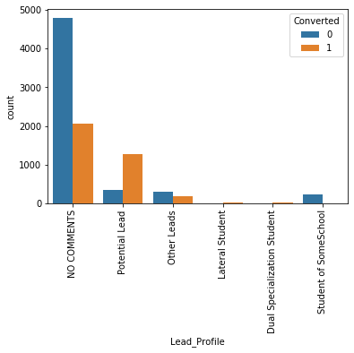

```python
sns.countplot(x='Lead_Profile', hue='Converted', data=score_df)
xticks(rotation=90)
plt.show()
```

```python
score_df.How_did_you_hear_about_X_Education.value_counts()
```

```
Online Search            808
Word Of Mouth            348
Student of SomeSchool    310
Other                    186
Multiple Sources         152
Advertisements            70
Social Media              67
Email                     26
SMS                       23
Name: How_did_you_hear_about_X_Education, dtype: int64
```

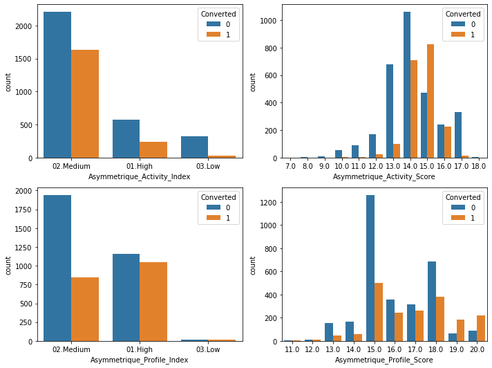

```python
fig, axs = plt.subplots(2,2, figsize = (10,7.5))
plt1 = sns.countplot(x='Asymmetrique_Activity_Index', hue='Converted', ax = axs[0,0], data=score_df)
plt2 = sns.countplot(x='Asymmetrique_Activity_Score', hue='Converted', ax = axs[0,1], data=score_df)
plt3 = sns.countplot(x='Asymmetrique_Profile_Index', hue='Converted', ax = axs[1,0], data=score_df)
plt4 = sns.countplot(x='Asymmetrique_Profile_Score', hue='Converted', ax = axs[1,1], data=score_df)
plt.tight_layout()
```

##### as the business significance of these assymetric index are not known and they are with siginificant nan values , need to be drooped

```python
score_df.Lead_Quality.value_counts()
```

```
Might be             1560
Not Sure             1092
High in Relevance     637
Worst                 601
Low in Relevance      583
Name: Lead_Quality, dtype: int64
```

#### lead quality is important from business point of view. let us impute with nan with new subcategory- "NO_COMMENTS". as it does not disturb the distibution.

```python
score_df['Lead_Quality']=score_df['Lead_Quality'].fillna('NO COMMENTS')
```

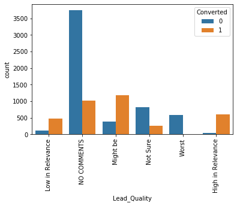

```python
sns.countplot(x='Lead_Quality', hue='Converted', data=score_df)
xticks(rotation=90)
plt.show()
```

```python
score_df.Tags.isna().value_counts()
```

```
False    5887
True     3353
Name: Tags, dtype: int64
```

#### Tags is important from business point of view. let us impute with nan with new subcategory- "NO_COMMENTS". as it does not disturb the distibution.

```python
score_df['Tags']=score_df['Tags'].fillna('NO COMMENTS')
```

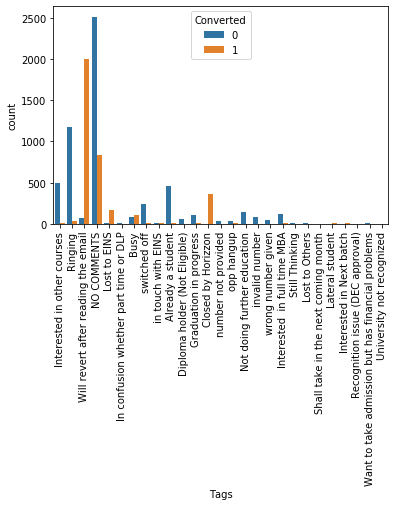

```python
sns.countplot(x='Tags', hue='Converted', data=score_df)
xticks(rotation=90)
plt.show()
```

#### let us replace low count sub-categories under Tags as others

```python
# theonly noteworthy concersion is from one category so we will change it to a 3 category field instead of so many columns

score_df['Tags'] = score_df['Tags'].replace(['Lost to EINS',
       'In confusion whether part time or DLP','in touch with EINS',
       'Diploma holder (Not Eligible)', 'Graduation in progress',
        'number not provided', 'opp hangup','invalid number',
       'wrong number given', 'Still Thinking', 'Lost to Others',
       'Shall take in the next coming month', 'Lateral student',
       'Interested in Next batch', 'Recognition issue (DEC approval)',
       'Want to take admission but has financial problems',
       'University not recognized'], 'OTHERS')
```

```python
score_df.Specialization.isna().value_counts()
```

```
False    5860
True     3380
Name: Specialization, dtype: int64
```

#### Imputing nan in Specilaisation with NO DATA

```python
score_df['Specialization']=score_df['Specialization'].fillna('NO DATA')
```

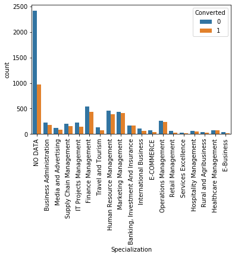

```python
sns.countplot(x='Specialization', hue='Converted', data=score_df)
xticks(rotation=90)
plt.show()
```

```python
score_df.City.isna().value_counts()
```

```
False    5571
True     3669
Name: City, dtype: int64
```

#### Imputing nan in City with NO DATA

```python
score_df['City']=score_df['City'].fillna('NO DATA')
```

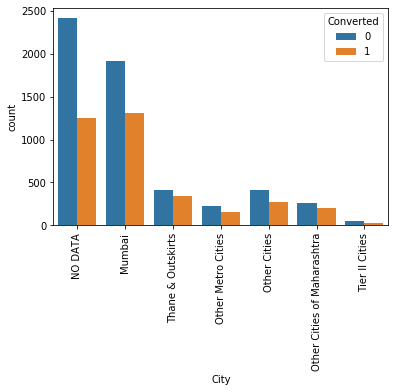

```python
sns.countplot(x='City', hue='Converted', data=score_df)
xticks(rotation=90)
plt.show()
```

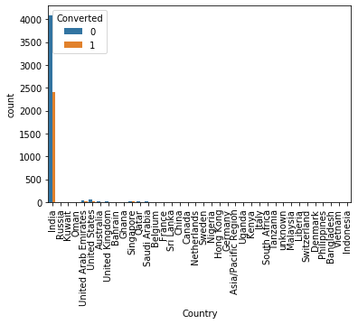

```python
sns.countplot(x='Country', hue='Converted', data=score_df)
xticks(rotation=90)
plt.show()
```

```python
score_df.What_matters_most_to_you_in_choosing_a_course.value_counts()
```

```
Better Career Prospects      6528
Flexibility & Convenience       2
Other                           1
Name: What_matters_most_to_you_in_choosing_a_course, dtype: int64
```

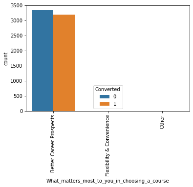

```python
sns.countplot(x='What_matters_most_to_you_in_choosing_a_course', hue='Converted', data=score_df)
xticks(rotation=90)
plt.show()
```

```python
score_df.What_is_your_current_occupation.isna().value_counts()
```

```
False    6550
True     2690
Name: What_is_your_current_occupation, dtype: int64
```

```python
score_df['What_is_your_current_occupation']=score_df['What_is_your_current_occupation'].fillna('NO DATA')
```

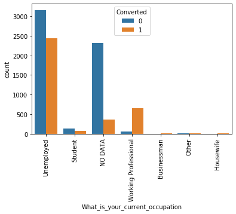

```python
sns.countplot(x='What_is_your_current_occupation', hue='Converted', data=score_df)
xticks(rotation=90)
plt.show()
```

```python
# replacing it with others where very less data is present to reduce categories and not lose data

score_df['What_is_your_current_occupation'] = score_df['What_is_your_current_occupation'].replace(['NO DATA','Businessman', 'Other', 'Housewife'],'OTHERS')
```

```python
 score_df.Last_Notable_Activity .isna().value_counts()
```

```
False    9240
Name: Last_Notable_Activity, dtype: int64
```

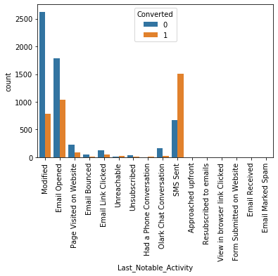

```python
sns.countplot(x='Last_Notable_Activity', hue='Converted', data=score_df)
xticks(rotation=90)
plt.show()
```

```python
 score_df.Last_Activity.isna().value_counts()
```

```
False    9137
True      103
Name: Last_Activity, dtype: int64
```

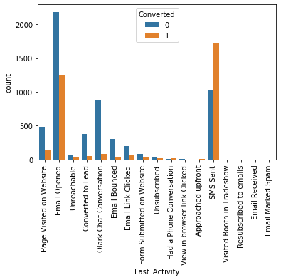

```python
sns.countplot(x='Last_Activity', hue='Converted', data=score_df)
xticks(rotation=90)
plt.show()
```

#### replace low count sub-categories with OTHERS.

```python
score_df['Last_Notable_Activity'] = score_df['Last_Notable_Activity'].replace(['Unreachable',
                 'Had a Phone Conversation',
                 'Approached upfront', 'Resubscribed to emails',
                 'View in browser link Clicked', 'Form Submitted on Website',
                 'Email Received', 'Email Marked Spam'], 'OTHERS')
```

```python
# Dropping MultipleLines_No phone service column
score_df['Lead_Source'] = score_df['Lead_Source'].replace(['blog', 'Pay per Click Ads', 'bing',
       'Social Media', 'WeLearn', 'Click2call', 'Live Chat',
       'welearnblog_Home', 'youtubechannel', 'testone', 'Press_Release',
       'NC_EDM'], 'OTHERS')

score_df['Lead_Source'] = score_df['Lead_Source'].replace(['google'], 'Google')
```

#### based on the above EDA on variables (with missing values ) and justification provided the follwoing variables are dropped

```python
# removing Prospect_ID since it is a unwanted id
# others since the nan values are above 40 percent
# Dropping Country since city provides the data redundant AND most business is from INDIA at present
# dropping 'What_matters_most_to_you_in_choosing_a_course' since it isa single response data rather a constant
# Dropping 'Last_Activity' since data is similar to Last_Notable_Activity

score_df = score_df.drop(['Prospect_ID','Lead_Profile','Lead_Quality','Country','Asymmetrique_Activity_Index','Asymmetrique_Profile_Index','Asymmetrique_Activity_Score',
               'Asymmetrique_Profile_Score','How_did_you_hear_about_X_Education','What_matters_most_to_you_in_choosing_a_course','Last_Activity'],1)
```

```python
# Checking the percentage of missing values
round(100*(score_df.isnull().sum()/len(score_df.index)), 2)
```

```
Lead_Number                                 0.00
Lead_Origin                                 0.00
Lead_Source                                 0.39
Do_Not_Email                                0.00
Do_Not_Call                                 0.00
Converted                                   0.00
TotalVisits                                 1.48
Total_Time_Spent_on_Website                 0.00
Page_Views_Per_Visit                        1.48
Specialization                              0.00
What_is_your_current_occupation             0.00
Search                                      0.00
Magazine                                    0.00
Newspaper_Article                           0.00
X_Education_Forums                          0.00
Newspaper                                   0.00
Digital_Advertisement                       0.00
Through_Recommendations                     0.00
Receive_More_Updates_About_Our_Courses      0.00
Tags                                        0.00
Update_me_on_Supply_Chain_Content           0.00
Get_updates_on_DM_Content                   0.00
City                                        0.00
I_agree_to_pay_the_amount_through_cheque    0.00
A_free_copy_of_Mastering_The_Interview      0.00
Last_Notable_Activity                       0.00
dtype: float64
```

```python
score_df.head(3)
```

|  | Lead_Number | Lead_Origin | Lead_Source | Do_Not_Email | Do_Not_Call | Converted | TotalVisits | Total_Time_Spent_on_Website | Page_Views_Per_Visit | Specialization | ... | Digital_Advertisement | Through_Recommendations | Receive_More_Updates_About_Our_Courses | Tags | Update_me_on_Supply_Chain_Content | Get_updates_on_DM_Content | City | I_agree_to_pay_the_amount_through_cheque | A_free_copy_of_Mastering_The_Interview | Last_Notable_Activity |
| --- | --- | --- | --- | --- | --- | --- | --- | --- | --- | --- | --- | --- | --- | --- | --- | --- | --- | --- | --- | --- | --- |
| 0 | 660737 | API | Olark Chat | No | No | 0 | 0.0 | 0 | 0.0 | NO DATA | ... | No | No | No | Interested in other courses | No | No | NO DATA | No | No | Modified |
| 1 | 660728 | API | Organic Search | No | No | 0 | 5.0 | 674 | 2.5 | NO DATA | ... | No | No | No | Ringing | No | No | NO DATA | No | No | Email Opened |
| 2 | 660727 | Landing Page Submission | Direct Traffic | No | No | 1 | 2.0 | 1532 | 2.0 | Business Administration | ... | No | No | No | Will revert after reading the email | No | No | Mumbai | No | Yes | Email Opened |

3 rows × 26 columns

```python
score_df.Do_Not_Email.describe()
```

```
count     9240
unique       2
top         No
freq      8506
Name: Do_Not_Email, dtype: object
```

```python
score_df.Do_Not_Call.describe()
```

```
count     9240
unique       2
top         No
freq      9238
Name: Do_Not_Call, dtype: object
```

```python
score_df.Search.describe()
```

```
count     9240
unique       2
top         No
freq      9226
Name: Search, dtype: object
```

```python
score_df.Magazine.describe()
```

```
count     9240
unique       1
top         No
freq      9240
Name: Magazine, dtype: object
```

```python
score_df.Newspaper_Article.describe()
```

```
count     9240
unique       2
top         No
freq      9238
Name: Newspaper_Article, dtype: object
```

```python
score_df.X_Education_Forums .describe()
```

```
count     9240
unique       2
top         No
freq      9239
Name: X_Education_Forums, dtype: object
```

```python
score_df.Newspaper.describe()
```

```
count     9240
unique       2
top         No
freq      9239
Name: Newspaper, dtype: object
```

```python
score_df.Digital_Advertisement .describe()
```

```
count     9240
unique       2
top         No
freq      9236
Name: Digital_Advertisement, dtype: object
```

```python
score_df.Through_Recommendations.describe()
```

```
count     9240
unique       2
top         No
freq      9233
Name: Through_Recommendations, dtype: object
```

```python
score_df.Receive_More_Updates_About_Our_Courses.describe()
```

```
count     9240
unique       1
top         No
freq      9240
Name: Receive_More_Updates_About_Our_Courses, dtype: object
```

```python
score_df.Update_me_on_Supply_Chain_Content.describe()
```

```
count     9240
unique       1
top         No
freq      9240
Name: Update_me_on_Supply_Chain_Content, dtype: object
```

```python
score_df.Get_updates_on_DM_Content.describe()
```

```
count     9240
unique       1
top         No
freq      9240
Name: Get_updates_on_DM_Content, dtype: object
```

```python
score_df.I_agree_to_pay_the_amount_through_cheque.describe()
```

```
count     9240
unique       1
top         No
freq      9240
Name: I_agree_to_pay_the_amount_through_cheque, dtype: object
```

```python
score_df.A_free_copy_of_Mastering_The_Interview.describe()
```

```
count     9240
unique       2
top         No
freq      6352
Name: A_free_copy_of_Mastering_The_Interview, dtype: object
```

```python
score_df.A_free_copy_of_Mastering_The_Interview.value_counts()
```

```
No     6352
Yes    2888
Name: A_free_copy_of_Mastering_The_Interview, dtype: int64
```

#### based on the EDA on the above binary variables, the variable does show an variation (i.e. data is almost a constant). The data with constant variance does not have information, hence need to be dropped.

```python
score_df = score_df.drop(['Do_Not_Email','Do_Not_Call','Search', 'Magazine',
       'Newspaper_Article', 'X_Education_Forums', 'Newspaper',
       'Digital_Advertisement', 'Through_Recommendations',
       'Receive_More_Updates_About_Our_Courses',
       'Update_me_on_Supply_Chain_Content', 'Get_updates_on_DM_Content', 'I_agree_to_pay_the_amount_through_cheque'],1)
```

#### Convert binary categorical variables

```python
# dropping columns since data is almost constant either yes or not

varlist =  ['A_free_copy_of_Mastering_The_Interview']

# Defining the map function
def binary_map(x):
    return x.map({'Yes': 1, "No": 0})

# Applying the function to the housing list
score_df[varlist] = score_df[varlist].apply(binary_map)
```

```python
score_df.columns
```

```
Index(['Lead_Number', 'Lead_Origin', 'Lead_Source', 'Converted', 'TotalVisits',
       'Total_Time_Spent_on_Website', 'Page_Views_Per_Visit', 'Specialization',
       'What_is_your_current_occupation', 'Tags', 'City',
       'A_free_copy_of_Mastering_The_Interview', 'Last_Notable_Activity'],
      dtype='object')
```

```python
score_df.isnull().sum()
```

```
Lead_Number                                 0
Lead_Origin                                 0
Lead_Source                                36
Converted                                   0
TotalVisits                               137
Total_Time_Spent_on_Website                 0
Page_Views_Per_Visit                      137
Specialization                              0
What_is_your_current_occupation             0
Tags                                        0
City                                        0
A_free_copy_of_Mastering_The_Interview      0
Last_Notable_Activity                       0
dtype: int64
```

```python
score_df['Specialization'].value_counts()
```

```
NO DATA                              3380
Finance Management                    976
Human Resource Management             848
Marketing Management                  838
Operations Management                 503
Business Administration               403
IT Projects Management                366
Supply Chain Management               349
Banking, Investment And Insurance     338
Media and Advertising                 203
Travel and Tourism                    203
International Business                178
Healthcare Management                 159
Hospitality Management                114
E-COMMERCE                            112
Retail Management                     100
Rural and Agribusiness                 73
E-Business                             57
Services Excellence                    40
Name: Specialization, dtype: int64
```

#### Converting categorical variables with multiple level using dummies

```python
# Creating dummy variables for the remaining categorical variables and dropping the level with big names.

# Creating dummy variables for the variable 'City
Sp1 = pd.get_dummies(score_df['Specialization'], prefix='Specialization')
#Adding the results to the master dataframe
score_df = pd.concat([score_df,Sp1], axis=1)
```

```python
Sp1.head()
```

|  | Specialization_Banking, Investment And Insurance | Specialization_Business Administration | Specialization_E-Business | Specialization_E-COMMERCE | Specialization_Finance Management | Specialization_Healthcare Management | Specialization_Hospitality Management | Specialization_Human Resource Management | Specialization_IT Projects Management | Specialization_International Business | Specialization_Marketing Management | Specialization_Media and Advertising | Specialization_NO DATA | Specialization_Operations Management | Specialization_Retail Management | Specialization_Rural and Agribusiness | Specialization_Services Excellence | Specialization_Supply Chain Management | Specialization_Travel and Tourism |
| --- | --- | --- | --- | --- | --- | --- | --- | --- | --- | --- | --- | --- | --- | --- | --- | --- | --- | --- | --- |
| 0 | 0 | 0 | 0 | 0 | 0 | 0 | 0 | 0 | 0 | 0 | 0 | 0 | 1 | 0 | 0 | 0 | 0 | 0 | 0 |
| 1 | 0 | 0 | 0 | 0 | 0 | 0 | 0 | 0 | 0 | 0 | 0 | 0 | 1 | 0 | 0 | 0 | 0 | 0 | 0 |
| 2 | 0 | 1 | 0 | 0 | 0 | 0 | 0 | 0 | 0 | 0 | 0 | 0 | 0 | 0 | 0 | 0 | 0 | 0 | 0 |
| 3 | 0 | 0 | 0 | 0 | 0 | 0 | 0 | 0 | 0 | 0 | 0 | 1 | 0 | 0 | 0 | 0 | 0 | 0 | 0 |
| 4 | 0 | 0 | 0 | 0 | 0 | 0 | 0 | 0 | 0 | 0 | 0 | 0 | 1 | 0 | 0 | 0 | 0 | 0 | 0 |

```python
# Creating dummy variables for the remaining categorical variables and dropping the level with big names.

# Creating dummy variables for the variable 'City
ct = pd.get_dummies(score_df['City'], prefix='City')
# Dropping MultipleLines_No phone service column
ct1 = ct.drop(['City_Tier II Cities'], 1)
#Adding the results to the master dataframe
score_df = pd.concat([score_df,ct1], axis=1)
```

```python
ct1.head()
```

|  | City_Mumbai | City_NO DATA | City_Other Cities | City_Other Cities of Maharashtra | City_Other Metro Cities | City_Thane & Outskirts |
| --- | --- | --- | --- | --- | --- | --- |
| 0 | 0 | 1 | 0 | 0 | 0 | 0 |
| 1 | 0 | 1 | 0 | 0 | 0 | 0 |
| 2 | 1 | 0 | 0 | 0 | 0 | 0 |
| 3 | 1 | 0 | 0 | 0 | 0 | 0 |
| 4 | 1 | 0 | 0 | 0 | 0 | 0 |

```python
# Creating dummy variables for the variable 'MultipleLines'

LS1= pd.get_dummies(score_df['Lead_Source'], prefix='Lead_Source')
#Adding the results to the master dataframe
score_df = pd.concat([score_df,LS1], axis=1)
```

```python
LS1.head()
```

|  | Lead_Source_Direct Traffic | Lead_Source_Facebook | Lead_Source_Google | Lead_Source_OTHERS | Lead_Source_Olark Chat | Lead_Source_Organic Search | Lead_Source_Reference | Lead_Source_Referral Sites | Lead_Source_Welingak Website |
| --- | --- | --- | --- | --- | --- | --- | --- | --- | --- |
| 0 | 0 | 0 | 0 | 0 | 1 | 0 | 0 | 0 | 0 |
| 1 | 0 | 0 | 0 | 0 | 0 | 1 | 0 | 0 | 0 |
| 2 | 1 | 0 | 0 | 0 | 0 | 0 | 0 | 0 | 0 |
| 3 | 1 | 0 | 0 | 0 | 0 | 0 | 0 | 0 | 0 |
| 4 | 0 | 0 | 1 | 0 | 0 | 0 | 0 | 0 | 0 |

```python
score_df['Lead_Origin'].value_counts()
```

```
Landing Page Submission    4886
API                        3580
Lead Add Form               718
Lead Import                  55
Quick Add Form                1
Name: Lead_Origin, dtype: int64
```

```python
# Creating dummy variables for the variable 'MultipleLines'
Lo= pd.get_dummies(score_df['Lead_Origin'], prefix='Lead_Origin')
# Dropping MultipleLines_No phone service column
Lo1 = Lo.drop(['Lead_Origin_Quick Add Form'], 1)
#Adding the results to the master dataframe
score_df = pd.concat([score_df,Lo1], axis=1)
```

```python
Lo1.head()
```

|  | Lead_Origin_API | Lead_Origin_Landing Page Submission | Lead_Origin_Lead Add Form | Lead_Origin_Lead Import |
| --- | --- | --- | --- | --- |
| 0 | 1 | 0 | 0 | 0 |
| 1 | 1 | 0 | 0 | 0 |
| 2 | 0 | 1 | 0 | 0 |
| 3 | 0 | 1 | 0 | 0 |
| 4 | 0 | 1 | 0 | 0 |

```python
score_df['What_is_your_current_occupation'].value_counts()
```

```
Unemployed              5600
OTHERS                  2724
Working Professional     706
Student                  210
Name: What_is_your_current_occupation, dtype: int64
```

```python
# Creating dummy variables for the variable 'MultipleLines'
CO= pd.get_dummies(score_df['What_is_your_current_occupation'], prefix='What_is_your_current_occupation')

#Adding the results to the master dataframe
score_df = pd.concat([score_df,CO], axis=1)
```

```python
CO.head(2)
```

|  | What_is_your_current_occupation_OTHERS | What_is_your_current_occupation_Student | What_is_your_current_occupation_Unemployed | What_is_your_current_occupation_Working Professional |
| --- | --- | --- | --- | --- |
| 0 | 0 | 0 | 1 | 0 |
| 1 | 0 | 0 | 1 | 0 |

```python
score_df['Tags'].value_counts()
```

```
NO COMMENTS                            3353
Will revert after reading the email    2072
Ringing                                1203
OTHERS                                  588
Interested in other courses             513
Already a student                       465
Closed by Horizzon                      358
switched off                            240
Busy                                    186
Not doing further education             145
Interested  in full time MBA            117
Name: Tags, dtype: int64
```

```python
# Creating dummy variables for the variable 'MultipleLines'
Tag= pd.get_dummies(score_df['Tags'], prefix='Tags')
#Adding the results to the master dataframe
score_df = pd.concat([score_df,Tag], axis=1)
```

```python
Tag.head()
```

|  | Tags_Already a student | Tags_Busy | Tags_Closed by Horizzon | Tags_Interested in full time MBA | Tags_Interested in other courses | Tags_NO COMMENTS | Tags_Not doing further education | Tags_OTHERS | Tags_Ringing | Tags_Will revert after reading the email | Tags_switched off |
| --- | --- | --- | --- | --- | --- | --- | --- | --- | --- | --- | --- |
| 0 | 0 | 0 | 0 | 0 | 1 | 0 | 0 | 0 | 0 | 0 | 0 |
| 1 | 0 | 0 | 0 | 0 | 0 | 0 | 0 | 0 | 1 | 0 | 0 |
| 2 | 0 | 0 | 0 | 0 | 0 | 0 | 0 | 0 | 0 | 1 | 0 |
| 3 | 0 | 0 | 0 | 0 | 0 | 0 | 0 | 0 | 1 | 0 | 0 |
| 4 | 0 | 0 | 0 | 0 | 0 | 0 | 0 | 0 | 0 | 1 | 0 |

```python
# Creating dummy variables for the variable 'MultipleLines'
LNA1= pd.get_dummies(score_df['Last_Notable_Activity'], prefix='Last_Notable_Activity')
#Adding the results to the master dataframe
score_df = pd.concat([score_df,LNA1], axis=1)
```

```python
LNA1.head(2)
```

|  | Last_Notable_Activity_Email Bounced | Last_Notable_Activity_Email Link Clicked | Last_Notable_Activity_Email Opened | Last_Notable_Activity_Modified | Last_Notable_Activity_OTHERS | Last_Notable_Activity_Olark Chat Conversation | Last_Notable_Activity_Page Visited on Website | Last_Notable_Activity_SMS Sent | Last_Notable_Activity_Unsubscribed |
| --- | --- | --- | --- | --- | --- | --- | --- | --- | --- |
| 0 | 0 | 0 | 0 | 1 | 0 | 0 | 0 | 0 | 0 |
| 1 | 0 | 0 | 1 | 0 | 0 | 0 | 0 | 0 | 0 |

```python
score_df.columns
```

```
Index(['Lead_Number', 'Lead_Origin', 'Lead_Source', 'Converted', 'TotalVisits',
       'Total_Time_Spent_on_Website', 'Page_Views_Per_Visit', 'Specialization',
       'What_is_your_current_occupation', 'Tags', 'City',
       'A_free_copy_of_Mastering_The_Interview', 'Last_Notable_Activity',
       'Specialization_Banking, Investment And Insurance',
       'Specialization_Business Administration', 'Specialization_E-Business',
       'Specialization_E-COMMERCE', 'Specialization_Finance Management',
       'Specialization_Healthcare Management',
       'Specialization_Hospitality Management',
       'Specialization_Human Resource Management',
       'Specialization_IT Projects Management',
       'Specialization_International Business',
       'Specialization_Marketing Management',
       'Specialization_Media and Advertising', 'Specialization_NO DATA',
       'Specialization_Operations Management',
       'Specialization_Retail Management',
       'Specialization_Rural and Agribusiness',
       'Specialization_Services Excellence',
       'Specialization_Supply Chain Management',
       'Specialization_Travel and Tourism', 'City_Mumbai', 'City_NO DATA',
       'City_Other Cities', 'City_Other Cities of Maharashtra',
       'City_Other Metro Cities', 'City_Thane & Outskirts',
       'Lead_Source_Direct Traffic', 'Lead_Source_Facebook',
       'Lead_Source_Google', 'Lead_Source_OTHERS', 'Lead_Source_Olark Chat',
       'Lead_Source_Organic Search', 'Lead_Source_Reference',
       'Lead_Source_Referral Sites', 'Lead_Source_Welingak Website',
       'Lead_Origin_API', 'Lead_Origin_Landing Page Submission',
       'Lead_Origin_Lead Add Form', 'Lead_Origin_Lead Import',
       'What_is_your_current_occupation_OTHERS',
       'What_is_your_current_occupation_Student',
       'What_is_your_current_occupation_Unemployed',
       'What_is_your_current_occupation_Working Professional',
       'Tags_Already a student', 'Tags_Busy', 'Tags_Closed by Horizzon',
       'Tags_Interested  in full time MBA', 'Tags_Interested in other courses',
       'Tags_NO COMMENTS', 'Tags_Not doing further education', 'Tags_OTHERS',
       'Tags_Ringing', 'Tags_Will revert after reading the email',
       'Tags_switched off', 'Last_Notable_Activity_Email Bounced',
       'Last_Notable_Activity_Email Link Clicked',
       'Last_Notable_Activity_Email Opened', 'Last_Notable_Activity_Modified',
       'Last_Notable_Activity_OTHERS',
       'Last_Notable_Activity_Olark Chat Conversation',
       'Last_Notable_Activity_Page Visited on Website',
       'Last_Notable_Activity_SMS Sent', 'Last_Notable_Activity_Unsubscribed'],
      dtype='object')
```

#### dropping the actual variables after creation of dummy varibales

```python
score_df=score_df.drop(['Last_Notable_Activity','Specialization',
       'What_is_your_current_occupation', 'Tags', 'City','Lead_Origin', 'Lead_Source'],1)
```

```python
score_df=score_df.drop('Lead_Number',1)
```

```python
# median
score_df.TotalVisits = score_df.TotalVisits.fillna(3)
```

```python
# median
score_df.Page_Views_Per_Visit = score_df.Page_Views_Per_Visit.fillna(2)
```

```python
score_df[['TotalVisits','Page_Views_Per_Visit']] = score_df[['TotalVisits','Page_Views_Per_Visit']].astype(int)
```

```python
# Putting feature variable to X
X=score_df.drop(['Converted'], axis=1)
X.head()
```

|  | TotalVisits | Total_Time_Spent_on_Website | Page_Views_Per_Visit | A_free_copy_of_Mastering_The_Interview | Specialization_Banking, Investment And Insurance | Specialization_Business Administration | Specialization_E-Business | Specialization_E-COMMERCE | Specialization_Finance Management | Specialization_Healthcare Management | ... | Tags_switched off | Last_Notable_Activity_Email Bounced | Last_Notable_Activity_Email Link Clicked | Last_Notable_Activity_Email Opened | Last_Notable_Activity_Modified | Last_Notable_Activity_OTHERS | Last_Notable_Activity_Olark Chat Conversation | Last_Notable_Activity_Page Visited on Website | Last_Notable_Activity_SMS Sent | Last_Notable_Activity_Unsubscribed |
| --- | --- | --- | --- | --- | --- | --- | --- | --- | --- | --- | --- | --- | --- | --- | --- | --- | --- | --- | --- | --- | --- |
| 0 | 0 | 0 | 0 | 0 | 0 | 0 | 0 | 0 | 0 | 0 | ... | 0 | 0 | 0 | 0 | 1 | 0 | 0 | 0 | 0 | 0 |
| 1 | 5 | 674 | 2 | 0 | 0 | 0 | 0 | 0 | 0 | 0 | ... | 0 | 0 | 0 | 1 | 0 | 0 | 0 | 0 | 0 | 0 |
| 2 | 2 | 1532 | 2 | 1 | 0 | 1 | 0 | 0 | 0 | 0 | ... | 0 | 0 | 0 | 1 | 0 | 0 | 0 | 0 | 0 | 0 |
| 3 | 1 | 305 | 1 | 0 | 0 | 0 | 0 | 0 | 0 | 0 | ... | 0 | 0 | 0 | 0 | 1 | 0 | 0 | 0 | 0 | 0 |
| 4 | 2 | 1428 | 1 | 0 | 0 | 0 | 0 | 0 | 0 | 0 | ... | 0 | 0 | 0 | 0 | 1 | 0 | 0 | 0 | 0 | 0 |

5 rows × 66 columns

### Step 4 Test-Train Split

```python
from sklearn.model_selection import train_test_split
```

```python
# Putting response variable to y
y=score_df['Converted']
y.head()
```

```
0    0
1    0
2    1
3    0
4    1
Name: Converted, dtype: int64
```

```python
# Splitting the data into train and test
X_train,X_test,y_train,y_test=train_test_split(X,y,train_size=0.7,test_size=0.3,random_state=100)
```

```python
X_train.head()
```

|  | TotalVisits | Total_Time_Spent_on_Website | Page_Views_Per_Visit | A_free_copy_of_Mastering_The_Interview | Specialization_Banking, Investment And Insurance | Specialization_Business Administration | Specialization_E-Business | Specialization_E-COMMERCE | Specialization_Finance Management | Specialization_Healthcare Management | ... | Tags_switched off | Last_Notable_Activity_Email Bounced | Last_Notable_Activity_Email Link Clicked | Last_Notable_Activity_Email Opened | Last_Notable_Activity_Modified | Last_Notable_Activity_OTHERS | Last_Notable_Activity_Olark Chat Conversation | Last_Notable_Activity_Page Visited on Website | Last_Notable_Activity_SMS Sent | Last_Notable_Activity_Unsubscribed |
| --- | --- | --- | --- | --- | --- | --- | --- | --- | --- | --- | --- | --- | --- | --- | --- | --- | --- | --- | --- | --- | --- |
| 1871 | 0 | 0 | 0 | 0 | 0 | 0 | 0 | 0 | 0 | 0 | ... | 0 | 0 | 0 | 1 | 0 | 0 | 0 | 0 | 0 | 0 |
| 6795 | 4 | 487 | 1 | 1 | 0 | 0 | 0 | 0 | 0 | 0 | ... | 0 | 0 | 0 | 1 | 0 | 0 | 0 | 0 | 0 | 0 |
| 3516 | 5 | 106 | 2 | 0 | 0 | 0 | 0 | 0 | 0 | 0 | ... | 0 | 0 | 0 | 1 | 0 | 0 | 0 | 0 | 0 | 0 |
| 8105 | 5 | 1230 | 5 | 0 | 0 | 0 | 0 | 0 | 0 | 0 | ... | 0 | 0 | 0 | 0 | 0 | 0 | 0 | 0 | 1 | 0 |
| 3934 | 0 | 0 | 0 | 0 | 0 | 0 | 0 | 0 | 0 | 0 | ... | 0 | 0 | 0 | 0 | 1 | 0 | 0 | 0 | 0 | 0 |

5 rows × 66 columns

```python
X_train.TotalVisits.head()
```

```
1871    0
6795    4
3516    5
8105    5
3934    0
Name: TotalVisits, dtype: int32
```

## Step 5 Feature Scaling

```python
from sklearn.preprocessing import StandardScaler
```

```python
scaler = StandardScaler()
X_train[['TotalVisits','Total_Time_Spent_on_Website','Page_Views_Per_Visit']]=scaler.fit_transform(X_train[['TotalVisits','Total_Time_Spent_on_Website','Page_Views_Per_Visit']])
X_train.head()
```

|  | TotalVisits | Total_Time_Spent_on_Website | Page_Views_Per_Visit | A_free_copy_of_Mastering_The_Interview | Specialization_Banking, Investment And Insurance | Specialization_Business Administration | Specialization_E-Business | Specialization_E-COMMERCE | Specialization_Finance Management | Specialization_Healthcare Management | ... | Tags_switched off | Last_Notable_Activity_Email Bounced | Last_Notable_Activity_Email Link Clicked | Last_Notable_Activity_Email Opened | Last_Notable_Activity_Modified | Last_Notable_Activity_OTHERS | Last_Notable_Activity_Olark Chat Conversation | Last_Notable_Activity_Page Visited on Website | Last_Notable_Activity_SMS Sent | Last_Notable_Activity_Unsubscribed |
| --- | --- | --- | --- | --- | --- | --- | --- | --- | --- | --- | --- | --- | --- | --- | --- | --- | --- | --- | --- | --- | --- |
| 1871 | -0.656434 | -0.885371 | -1.051699 | 0 | 0 | 0 | 0 | 0 | 0 | 0 | ... | 0 | 0 | 0 | 1 | 0 | 0 | 0 | 0 | 0 | 0 |
| 6795 | 0.100767 | 0.005716 | -0.590301 | 1 | 0 | 0 | 0 | 0 | 0 | 0 | ... | 0 | 0 | 0 | 1 | 0 | 0 | 0 | 0 | 0 | 0 |
| 3516 | 0.290067 | -0.691418 | -0.128903 | 0 | 0 | 0 | 0 | 0 | 0 | 0 | ... | 0 | 0 | 0 | 1 | 0 | 0 | 0 | 0 | 0 | 0 |
| 8105 | 0.290067 | 1.365219 | 1.255291 | 0 | 0 | 0 | 0 | 0 | 0 | 0 | ... | 0 | 0 | 0 | 0 | 0 | 0 | 0 | 0 | 1 | 0 |
| 3934 | -0.656434 | -0.885371 | -1.051699 | 0 | 0 | 0 | 0 | 0 | 0 | 0 | ... | 0 | 0 | 0 | 0 | 1 | 0 | 0 | 0 | 0 | 0 |

5 rows × 66 columns

```python
### Checking the Conversion Rate
ConvRate= (sum(score_df['Converted'])/len(score_df['Converted'].index))*100
ConvRate
```

```
38.53896103896104
```

```python
score_df.info()
```

```
<class 'pandas.core.frame.DataFrame'>
RangeIndex: 9240 entries, 0 to 9239
Data columns (total 67 columns):
Converted                                               9240 non-null int64
TotalVisits                                             9240 non-null int32
Total_Time_Spent_on_Website                             9240 non-null int64
Page_Views_Per_Visit                                    9240 non-null int32
A_free_copy_of_Mastering_The_Interview                  9240 non-null int64
Specialization_Banking, Investment And Insurance        9240 non-null uint8
Specialization_Business Administration                  9240 non-null uint8
Specialization_E-Business                               9240 non-null uint8
Specialization_E-COMMERCE                               9240 non-null uint8
Specialization_Finance Management                       9240 non-null uint8
Specialization_Healthcare Management                    9240 non-null uint8
Specialization_Hospitality Management                   9240 non-null uint8
Specialization_Human Resource Management                9240 non-null uint8
Specialization_IT Projects Management                   9240 non-null uint8
Specialization_International Business                   9240 non-null uint8
Specialization_Marketing Management                     9240 non-null uint8
Specialization_Media and Advertising                    9240 non-null uint8
Specialization_NO DATA                                  9240 non-null uint8
Specialization_Operations Management                    9240 non-null uint8
Specialization_Retail Management                        9240 non-null uint8
Specialization_Rural and Agribusiness                   9240 non-null uint8
Specialization_Services Excellence                      9240 non-null uint8
Specialization_Supply Chain Management                  9240 non-null uint8
Specialization_Travel and Tourism                       9240 non-null uint8
City_Mumbai                                             9240 non-null uint8
City_NO DATA                                            9240 non-null uint8
City_Other Cities                                       9240 non-null uint8
City_Other Cities of Maharashtra                        9240 non-null uint8
City_Other Metro Cities                                 9240 non-null uint8
City_Thane & Outskirts                                  9240 non-null uint8
Lead_Source_Direct Traffic                              9240 non-null uint8
Lead_Source_Facebook                                    9240 non-null uint8
Lead_Source_Google                                      9240 non-null uint8
Lead_Source_OTHERS                                      9240 non-null uint8
Lead_Source_Olark Chat                                  9240 non-null uint8
Lead_Source_Organic Search                              9240 non-null uint8
Lead_Source_Reference                                   9240 non-null uint8
```

[output cut: 17 more lines]

```
Tags_OTHERS                                             9240 non-null uint8
Tags_Ringing                                            9240 non-null uint8
Tags_Will revert after reading the email                9240 non-null uint8
Tags_switched off                                       9240 non-null uint8
Last_Notable_Activity_Email Bounced                     9240 non-null uint8
Last_Notable_Activity_Email Link Clicked                9240 non-null uint8
Last_Notable_Activity_Email Opened                      9240 non-null uint8
Last_Notable_Activity_Modified                          9240 non-null uint8
Last_Notable_Activity_OTHERS                            9240 non-null uint8
Last_Notable_Activity_Olark Chat Conversation           9240 non-null uint8
Last_Notable_Activity_Page Visited on Website           9240 non-null uint8
Last_Notable_Activity_SMS Sent                          9240 non-null uint8
Last_Notable_Activity_Unsubscribed                      9240 non-null uint8
dtypes: int32(2), int64(3), uint8(62)
memory usage: 848.3 KB
```

```python
# Importing matplotlib and seaborn
import matplotlib.pyplot as plt
import seaborn as sns
%matplotlib inline
```

### Looking at Correlations

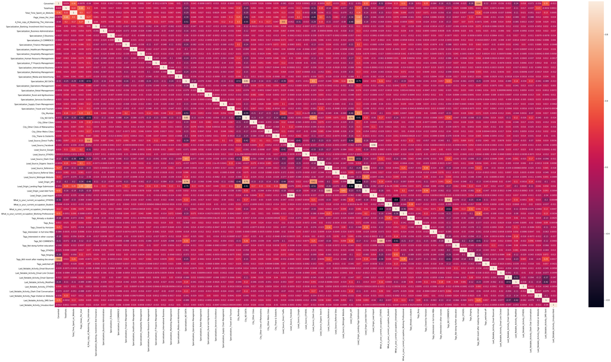

```python
# Let's see the correlation matrix
plt.figure(figsize = (60,30))        # Size of the figure
sns.heatmap(score_df.corr(),annot = True)
plt.show()
```

## Buliding Logistic Regression Model

```python
import statsmodels.api as sm
```

```python
# Logistic regression model
logm1 = sm.GLM(y_train,(sm.add_constant(X_train)), family = sm.families.Binomial())
logm1.fit().summary()
```

Generalized Linear Model Regression Results

| Dep. Variable: | Converted | No. Observations: | 6468 |
| --- | --- | --- | --- |
| Model: | GLM | Df Residuals: | 6405 |
| Model Family: | Binomial | Df Model: | 62 |
| Link Function: | logit | Scale: | 1.0000 |
| Method: | IRLS | Log-Likelihood: | nan |
| Date: | Mon, 02 Mar 2020 | Deviance: | nan |
| Time: | 14:02:43 | Pearson chi2: | 3.37e+18 |
| No. Iterations: | 100 |  |  |
| Covariance Type: | nonrobust |  |  |

|  | coef | std err | z | P>\|z\| | [0.025 | 0.975] |
| --- | --- | --- | --- | --- | --- | --- |
| const | 5.12e+14 | 4.56e+07 | 1.12e+07 | 0.000 | 5.12e+14 | 5.12e+14 |
| TotalVisits | 3.81e+13 | 9.83e+05 | 3.87e+07 | 0.000 | 3.81e+13 | 3.81e+13 |
| Total_Time_Spent_on_Website | 3.275e+14 | 9.96e+05 | 3.29e+08 | 0.000 | 3.27e+14 | 3.27e+14 |
| Page_Views_Per_Visit | -2.061e+13 | 1.14e+06 | -1.8e+07 | 0.000 | -2.06e+13 | -2.06e+13 |
| A_free_copy_of_Mastering_The_Interview | 9.422e+12 | 2.71e+06 | 3.48e+06 | 0.000 | 9.42e+12 | 9.42e+12 |
| Specialization_Banking, Investment And Insurance | 1.006e+14 | 5.13e+06 | 1.96e+07 | 0.000 | 1.01e+14 | 1.01e+14 |
| Specialization_Business Administration | 1.071e+14 | 4.75e+06 | 2.26e+07 | 0.000 | 1.07e+14 | 1.07e+14 |
| Specialization_E-Business | -4.596e+13 | 1.09e+07 | -4.23e+06 | 0.000 | -4.6e+13 | -4.6e+13 |
| Specialization_E-COMMERCE | 2.084e+14 | 7.3e+06 | 2.86e+07 | 0.000 | 2.08e+14 | 2.08e+14 |
| Specialization_Finance Management | 2.071e+14 | 3.78e+06 | 5.48e+07 | 0.000 | 2.07e+14 | 2.07e+14 |
| Specialization_Healthcare Management | 9.062e+13 | 6.98e+06 | 1.3e+07 | 0.000 | 9.06e+13 | 9.06e+13 |
| Specialization_Hospitality Management | -1.733e+14 | 7.42e+06 | -2.33e+07 | 0.000 | -1.73e+14 | -1.73e+14 |
| Specialization_Human Resource Management | 8.88e+13 | 3.88e+06 | 2.29e+07 | 0.000 | 8.88e+13 | 8.88e+13 |
| Specialization_IT Projects Management | 1.841e+14 | 5.02e+06 | 3.67e+07 | 0.000 | 1.84e+14 | 1.84e+14 |
| Specialization_International Business | -3.137e+14 | 6.45e+06 | -4.86e+07 | 0.000 | -3.14e+14 | -3.14e+14 |
| Specialization_Marketing Management | 7.842e+13 | 3.88e+06 | 2.02e+07 | 0.000 | 7.84e+13 | 7.84e+13 |
| Specialization_Media and Advertising | 9.013e+13 | 6.24e+06 | 1.44e+07 | 0.000 | 9.01e+13 | 9.01e+13 |
| Specialization_NO DATA | -2.14e+13 | 4.59e+06 | -4.66e+06 | 0.000 | -2.14e+13 | -2.14e+13 |
| Specialization_Operations Management | 5.714e+13 | 4.39e+06 | 1.3e+07 | 0.000 | 5.71e+13 | 5.71e+13 |
| Specialization_Retail Management | -3.769e+13 | 8.14e+06 | -4.63e+06 | 0.000 | -3.77e+13 | -3.77e+13 |
| Specialization_Rural and Agribusiness | 2.897e+14 | 9.8e+06 | 2.96e+07 | 0.000 | 2.9e+14 | 2.9e+14 |
| Specialization_Services Excellence | -1.249e+14 | 1.18e+07 | -1.06e+07 | 0.000 | -1.25e+14 | -1.25e+14 |
| Specialization_Supply Chain Management | -8.444e+13 | 4.99e+06 | -1.69e+07 | 0.000 | -8.44e+13 | -8.44e+13 |
| Specialization_Travel and Tourism | -1.886e+14 | 6.19e+06 | -3.05e+07 | 0.000 | -1.89e+14 | -1.89e+14 |
| City_Mumbai | -3.898e+13 | 9.61e+06 | -4.05e+06 | 0.000 | -3.9e+13 | -3.9e+13 |
| City_NO DATA | -4.067e+13 | 1.04e+07 | -3.93e+06 | 0.000 | -4.07e+13 | -4.07e+13 |
| City_Other Cities | 7.006e+12 | 9.94e+06 | 7.05e+05 | 0.000 | 7.01e+12 | 7.01e+12 |
| City_Other Cities of Maharashtra | -6.094e+13 | 1.02e+07 | -5.96e+06 | 0.000 | -6.09e+13 | -6.09e+13 |
| City_Other Metro Cities | -6.613e+13 | 1.03e+07 | -6.39e+06 | 0.000 | -6.61e+13 | -6.61e+13 |
| City_Thane & Outskirts | -1.114e+14 | 9.98e+06 | -1.12e+07 | 0.000 | -1.11e+14 | -1.11e+14 |
| Lead_Source_Direct Traffic | -4.066e+14 | 2.83e+07 | -1.44e+07 | 0.000 | -4.07e+14 | -4.07e+14 |
| Lead_Source_Facebook | -5.548e+14 | 5.02e+07 | -1.1e+07 | 0.000 | -5.55e+14 | -5.55e+14 |
| Lead_Source_Google | -3.117e+14 | 2.82e+07 | -1.1e+07 | 0.000 | -3.12e+14 | -3.12e+14 |
| Lead_Source_OTHERS | -7.74e+13 | 2.73e+07 | -2.83e+06 | 0.000 | -7.74e+13 | -7.74e+13 |
| Lead_Source_Olark Chat | -1.884e+14 | 2.83e+07 | -6.66e+06 | 0.000 | -1.88e+14 | -1.88e+14 |
| Lead_Source_Organic Search | -3.802e+14 | 2.83e+07 | -1.34e+07 | 0.000 | -3.8e+14 | -3.8e+14 |
| Lead_Source_Reference | -2.279e+14 | 1.4e+07 | -1.63e+07 | 0.000 | -2.28e+14 | -2.28e+14 |
| Lead_Source_Referral Sites | -4.824e+14 | 2.91e+07 | -1.66e+07 | 0.000 | -4.82e+14 | -4.82e+14 |
| Lead_Source_Welingak Website | -6.89e+14 | 1.52e+07 | -4.53e+07 | 0.000 | -6.89e+14 | -6.89e+14 |
| Lead_Origin_API | -1.326e+15 | 7.36e+07 | -1.8e+07 | 0.000 | -1.33e+15 | -1.33e+15 |
| Lead_Origin_Landing Page Submission | -1.515e+15 | 7.35e+07 | -2.06e+07 | 0.000 | -1.52e+15 | -1.52e+15 |
| Lead_Origin_Lead Add Form | -1.047e+15 | 6.92e+07 | -1.51e+07 | 0.000 | -1.05e+15 | -1.05e+15 |
| Lead_Origin_Lead Import | -1.345e+15 | 8.43e+07 | -1.6e+07 | 0.000 | -1.34e+15 | -1.34e+15 |
| What_is_your_current_occupation_OTHERS | -8.914e+14 | 1.18e+07 | -7.52e+07 | 0.000 | -8.91e+14 | -8.91e+14 |
| What_is_your_current_occupation_Student | 3.088e+14 | 1.24e+07 | 2.5e+07 | 0.000 | 3.09e+14 | 3.09e+14 |
| What_is_your_current_occupation_Unemployed | 4.723e+14 | 1.15e+07 | 4.11e+07 | 0.000 | 4.72e+14 | 4.72e+14 |
| What_is_your_current_occupation_Working Professional | 6.223e+14 | 1.18e+07 | 5.28e+07 | 0.000 | 6.22e+14 | 6.22e+14 |
| Tags_Already a student | -1.588e+15 | 5.66e+06 | -2.81e+08 | 0.000 | -1.59e+15 | -1.59e+15 |
| Tags_Busy | -6.582e+14 | 7.08e+06 | -9.3e+07 | 0.000 | -6.58e+14 | -6.58e+14 |
| Tags_Closed by Horizzon | 1.687e+15 | 6.25e+06 | 2.7e+08 | 0.000 | 1.69e+15 | 1.69e+15 |
| Tags_Interested in full time MBA | -6.331e+13 | 8.14e+06 | -7.78e+06 | 0.000 | -6.33e+13 | -6.33e+13 |
| Tags_Interested in other courses | 5.172e+13 | 5.45e+06 | 9.48e+06 | 0.000 | 5.17e+13 | 5.17e+13 |
| Tags_NO COMMENTS | 1.783e+15 | 5.01e+06 | 3.56e+08 | 0.000 | 1.78e+15 | 1.78e+15 |
| Tags_Not doing further education | -3.156e+14 | 7.38e+06 | -4.28e+07 | 0.000 | -3.16e+14 | -3.16e+14 |
| Tags_OTHERS | -6.167e+14 | 5.33e+06 | -1.16e+08 | 0.000 | -6.17e+14 | -6.17e+14 |
| Tags_Ringing | -3.565e+14 | 4.89e+06 | -7.3e+07 | 0.000 | -3.57e+14 | -3.57e+14 |
| Tags_Will revert after reading the email | 9.718e+14 | 4.83e+06 | 2.01e+08 | 0.000 | 9.72e+14 | 9.72e+14 |
| Tags_switched off | -3.837e+14 | 6.33e+06 | -6.06e+07 | 0.000 | -3.84e+14 | -3.84e+14 |
| Last_Notable_Activity_Email Bounced | -9.797e+13 | 1.11e+07 | -8.85e+06 | 0.000 | -9.8e+13 | -9.8e+13 |
| Last_Notable_Activity_Email Link Clicked | -6.864e+13 | 7.81e+06 | -8.79e+06 | 0.000 | -6.86e+13 | -6.86e+13 |
| Last_Notable_Activity_Email Opened | 2.462e+14 | 5.72e+06 | 4.3e+07 | 0.000 | 2.46e+14 | 2.46e+14 |
| Last_Notable_Activity_Modified | -6.706e+12 | 5.67e+06 | -1.18e+06 | 0.000 | -6.71e+12 | -6.71e+12 |
| Last_Notable_Activity_OTHERS | 3.257e+14 | 1.15e+07 | 2.84e+07 | 0.000 | 3.26e+14 | 3.26e+14 |
| Last_Notable_Activity_Olark Chat Conversation | -2.782e+14 | 7.87e+06 | -3.53e+07 | 0.000 | -2.78e+14 | -2.78e+14 |
| Last_Notable_Activity_Page Visited on Website | -7.375e+13 | 6.89e+06 | -1.07e+07 | 0.000 | -7.37e+13 | -7.37e+13 |
| Last_Notable_Activity_SMS Sent | 7.067e+14 | 5.84e+06 | 1.21e+08 | 0.000 | 7.07e+14 | 7.07e+14 |
| Last_Notable_Activity_Unsubscribed | -2.413e+14 | 1.22e+07 | -1.98e+07 | 0.000 | -2.41e+14 | -2.41e+14 |

### Feature Selection Using RFE

```python
from sklearn.linear_model import LogisticRegression
logreg = LogisticRegression()
```

```python
from sklearn.feature_selection import RFE
rfe = RFE(logreg, 15)             # running RFE with 13 variables as output
rfe = rfe.fit(X_train, y_train)
```

```python
rfe.support_
```

```
array([False,  True, False, False, False, False, False, False, False,
       False, False, False, False, False, False, False, False, False,
       False, False, False, False,  True, False, False, False, False,
       False, False, False, False, False, False, False, False, False,
       False,  True, False, False,  True, False,  True, False, False,
       False,  True, False,  True,  True,  True, False,  True, False,
        True,  True,  True, False, False, False, False,  True, False,
       False,  True, False])
```

```python
col = X_train.columns[rfe.support_]
col
```

```
Index(['Total_Time_Spent_on_Website', 'Specialization_Travel and Tourism',
       'Lead_Source_Welingak Website', 'Lead_Origin_Lead Add Form',
       'What_is_your_current_occupation_OTHERS', 'Tags_Already a student',
       'Tags_Closed by Horizzon', 'Tags_Interested  in full time MBA',
       'Tags_Interested in other courses', 'Tags_Not doing further education',
       'Tags_Ringing', 'Tags_Will revert after reading the email',
       'Tags_switched off', 'Last_Notable_Activity_OTHERS',
       'Last_Notable_Activity_SMS Sent'],
      dtype='object')
```

```python
X_train_sm = sm.add_constant(X_train[col])
logm2 = sm.GLM(y_train,X_train_sm, family = sm.families.Binomial())
res = logm2.fit()
res.summary()
```

Generalized Linear Model Regression Results

| Dep. Variable: | Converted | No. Observations: | 6468 |
| --- | --- | --- | --- |
| Model: | GLM | Df Residuals: | 6452 |
| Model Family: | Binomial | Df Model: | 15 |
| Link Function: | logit | Scale: | 1.0000 |
| Method: | IRLS | Log-Likelihood: | -1447.6 |
| Date: | Mon, 02 Mar 2020 | Deviance: | 2895.2 |
| Time: | 14:02:44 | Pearson chi2: | 7.52e+03 |
| No. Iterations: | 8 |  |  |
| Covariance Type: | nonrobust |  |  |

|  | coef | std err | z | P>\|z\| | [0.025 | 0.975] |
| --- | --- | --- | --- | --- | --- | --- |
| const | -0.7052 | 0.083 | -8.461 | 0.000 | -0.869 | -0.542 |
| Total_Time_Spent_on_Website | 0.8774 | 0.049 | 17.933 | 0.000 | 0.782 | 0.973 |
| Specialization_Travel and Tourism | -1.1729 | 0.369 | -3.181 | 0.001 | -1.895 | -0.450 |
| Lead_Source_Welingak Website | 3.0108 | 0.785 | 3.834 | 0.000 | 1.472 | 4.550 |
| Lead_Origin_Lead Add Form | 1.2264 | 0.304 | 4.038 | 0.000 | 0.631 | 1.822 |
| What_is_your_current_occupation_OTHERS | -1.4676 | 0.109 | -13.521 | 0.000 | -1.680 | -1.255 |
| Tags_Already a student | -4.4102 | 0.718 | -6.143 | 0.000 | -5.817 | -3.003 |
| Tags_Closed by Horizzon | 5.6754 | 1.013 | 5.600 | 0.000 | 3.689 | 7.662 |
| Tags_Interested in full time MBA | -3.1390 | 0.735 | -4.273 | 0.000 | -4.579 | -1.699 |
| Tags_Interested in other courses | -3.0078 | 0.335 | -8.990 | 0.000 | -3.664 | -2.352 |
| Tags_Not doing further education | -4.1833 | 1.014 | -4.125 | 0.000 | -6.171 | -2.196 |
| Tags_Ringing | -4.2554 | 0.238 | -17.866 | 0.000 | -4.722 | -3.789 |
| Tags_Will revert after reading the email | 3.3057 | 0.177 | 18.658 | 0.000 | 2.958 | 3.653 |
| Tags_switched off | -4.4398 | 0.528 | -8.414 | 0.000 | -5.474 | -3.406 |
| Last_Notable_Activity_OTHERS | 1.1614 | 0.603 | 1.926 | 0.054 | -0.021 | 2.343 |
| Last_Notable_Activity_SMS Sent | 2.1102 | 0.120 | 17.548 | 0.000 | 1.874 | 2.346 |

```python
y_train_pred = res.predict(X_train_sm).values.reshape(-1)
```

```python
y_train_pred[:10]
```

```
array([0.00321265, 0.33177093, 0.0038064 , 0.16076937, 0.18511546,
       0.99824797, 0.00368067, 0.99744521, 0.16229834, 0.99841116])
```

##### Creating a dataframe with the actual and the predicted probabilities

```python
y_train_pred_final = pd.DataFrame({'Converted':y_train.values, 'Conv_Prob':y_train_pred})
y_train_pred_final['CustID'] = y_train.index
y_train_pred_final.head()
```

|  | Converted | Conv_Prob | CustID |
| --- | --- | --- | --- |
| 0 | 0 | 0.003213 | 1871 |
| 1 | 0 | 0.331771 | 6795 |
| 2 | 0 | 0.003806 | 3516 |
| 3 | 0 | 0.160769 | 8105 |
| 4 | 0 | 0.185115 | 3934 |

```python
y_train_pred_final['predicted'] = y_train_pred_final.Conv_Prob.map(lambda x: 1 if x > 0.4 else 0)

# Let's see the head
y_train_pred_final.head(20)
```

|  | Converted | Conv_Prob | CustID | predicted |
| --- | --- | --- | --- | --- |
| 0 | 0 | 0.003213 | 1871 | 0 |
| 1 | 0 | 0.331771 | 6795 | 0 |
| 2 | 0 | 0.003806 | 3516 | 0 |
| 3 | 0 | 0.160769 | 8105 | 0 |
| 4 | 0 | 0.185115 | 3934 | 0 |
| 5 | 1 | 0.998248 | 4844 | 1 |
| 6 | 0 | 0.003681 | 3297 | 0 |
| 7 | 1 | 0.997445 | 8071 | 1 |
| 8 | 0 | 0.162298 | 987 | 0 |
| 9 | 1 | 0.998411 | 7423 | 1 |
| 10 | 1 | 0.944740 | 1032 | 1 |
| 11 | 0 | 0.707851 | 6542 | 1 |
| 12 | 1 | 0.883819 | 4317 | 1 |
| 13 | 1 | 0.877729 | 6472 | 1 |
| 14 | 0 | 0.004090 | 712 | 0 |
| 15 | 0 | 0.049750 | 3960 | 0 |
| 16 | 0 | 0.049750 | 4654 | 0 |
| 17 | 0 | 0.067018 | 5902 | 0 |
| 18 | 0 | 0.049750 | 4691 | 0 |
| 19 | 1 | 0.921594 | 4341 | 1 |

### looking at the model metrics

```python
from sklearn import metrics
```

```python
# Confusion matrix
confusion = metrics.confusion_matrix(y_train_pred_final.Converted, y_train_pred_final.predicted )
print(confusion)
```

```
[[3770  232]
 [ 317 2149]]
```

```python
# Let's check the overall accuracy.
print(metrics.accuracy_score(y_train_pred_final.Converted, y_train_pred_final.predicted))
```

```
0.9151205936920223
```

### Checking vif

```python
# Check for the VIF values of the feature variables.
from statsmodels.stats.outliers_influence import variance_inflation_factor
```

```python
# Create a dataframe that will contain the names of all the feature variables and their respective VIFs
vif = pd.DataFrame()
vif['Features'] = X_train[col].columns
vif['VIF'] = [variance_inflation_factor(X_train[col].values, i) for i in range(X_train[col].shape[1])]
vif['VIF'] = round(vif['VIF'], 2)
vif = vif.sort_values(by = "VIF", ascending = False)
vif
```

|  | Features | VIF |
| --- | --- | --- |
| 3 | Lead_Origin_Lead Add Form | 1.73 |
| 11 | Tags_Will revert after reading the email | 1.54 |
| 14 | Last_Notable_Activity_SMS Sent | 1.46 |
| 2 | Lead_Source_Welingak Website | 1.26 |
| 6 | Tags_Closed by Horizzon | 1.24 |
| 0 | Total_Time_Spent_on_Website | 1.19 |
| 10 | Tags_Ringing | 1.09 |
| 4 | What_is_your_current_occupation_OTHERS | 1.05 |
| 12 | Tags_switched off | 1.03 |
| 1 | Specialization_Travel and Tourism | 1.02 |
| 13 | Last_Notable_Activity_OTHERS | 1.02 |
| 5 | Tags_Already a student | 1.01 |
| 8 | Tags_Interested in other courses | 1.01 |
| 7 | Tags_Interested in full time MBA | 1.00 |
| 9 | Tags_Not doing further education | 1.00 |

### vif profile looks ideal hence not removing and parameters

### Metrics beyond simply accuracy

```python
TP = confusion[1,1] # true positive
TN = confusion[0,0] # true negatives
FP = confusion[0,1] # false positives
FN = confusion[1,0] # false negatives
```

```python
# Let's see the sensitivity of our logistic regression model
TP / float(TP+FN)
```

```
0.8714517437145174
```

```python
# Let us calculate specificity
TN / float(TN+FP)
```

```
0.9420289855072463
```

```python
# Calculate false postive rate - predicting churn when customer does not have churned
print(FP/ float(TN+FP))
```

```
0.057971014492753624
```

```python
# positive predictive value
print (TP / float(TP+FP))
```

```
0.9025619487610248
```

```python
# Negative predictive value
print (TN / float(TN+ FN))
```

```
0.9224369953511132
```

### ROC Curve

```python
def draw_roc( actual, probs ):
    fpr, tpr, thresholds = metrics.roc_curve( actual, probs,
                                              drop_intermediate = False )
    auc_score = metrics.roc_auc_score( actual, probs )
    plt.figure(figsize=(5, 5))
    plt.plot( fpr, tpr, label='ROC curve (area = %0.2f)' % auc_score )
    plt.plot([0, 1], [0, 1], 'k--')
    plt.xlim([0.0, 1.0])
    plt.ylim([0.0, 1.05])
    plt.xlabel('False Positive Rate or [1 - True Negative Rate]')
    plt.ylabel('True Positive Rate')
    plt.title('Receiver operating characteristic example')
    plt.legend(loc="lower right")
    plt.show()

    return None
```

```python
fpr, tpr, thresholds = metrics.roc_curve( y_train_pred_final.Converted, y_train_pred_final.Conv_Prob, drop_intermediate = False )
```

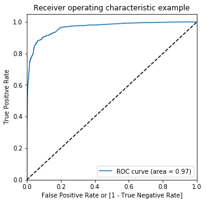

```python
draw_roc(y_train_pred_final.Converted, y_train_pred_final.Conv_Prob)
```

### finding optimal cutoff

```python
# Let's create columns with different probability cutoffs
numbers = [float(x)/10 for x in range(10)]
for i in numbers:
    y_train_pred_final[i]= y_train_pred_final.Conv_Prob.map(lambda x: 1 if x > i else 0)
y_train_pred_final.head()
```

|  | Converted | Conv_Prob | CustID | predicted | 0.0 | 0.1 | 0.2 | 0.3 | 0.4 | 0.5 | 0.6 | 0.7 | 0.8 | 0.9 |
| --- | --- | --- | --- | --- | --- | --- | --- | --- | --- | --- | --- | --- | --- | --- |
| 0 | 0 | 0.003213 | 1871 | 0 | 1 | 0 | 0 | 0 | 0 | 0 | 0 | 0 | 0 | 0 |
| 1 | 0 | 0.331771 | 6795 | 0 | 1 | 1 | 1 | 1 | 0 | 0 | 0 | 0 | 0 | 0 |
| 2 | 0 | 0.003806 | 3516 | 0 | 1 | 0 | 0 | 0 | 0 | 0 | 0 | 0 | 0 | 0 |
| 3 | 0 | 0.160769 | 8105 | 0 | 1 | 1 | 0 | 0 | 0 | 0 | 0 | 0 | 0 | 0 |
| 4 | 0 | 0.185115 | 3934 | 0 | 1 | 1 | 0 | 0 | 0 | 0 | 0 | 0 | 0 | 0 |

```python
# Now let's calculate accuracy sensitivity and specificity for various probability cutoffs.
cutoff_df = pd.DataFrame( columns = ['prob','accuracy','sensi','speci'])
from sklearn.metrics import confusion_matrix

# TP = confusion[1,1] # true positive
# TN = confusion[0,0] # true negatives
# FP = confusion[0,1] # false positives
# FN = confusion[1,0] # false negatives

num = [0.0,0.1,0.2,0.3,0.4,0.5,0.6,0.7,0.8,0.9]
for i in num:
    cm1 = metrics.confusion_matrix(y_train_pred_final.Converted, y_train_pred_final[i] )
    total1=sum(sum(cm1))
    accuracy = (cm1[0,0]+cm1[1,1])/total1

    speci = cm1[0,0]/(cm1[0,0]+cm1[0,1])
    sensi = cm1[1,1]/(cm1[1,0]+cm1[1,1])
    cutoff_df.loc[i] =[ i ,accuracy,sensi,speci]
print(cutoff_df)
```

```
     prob  accuracy     sensi     speci
0.0   0.0  0.381262  1.000000  0.000000
0.1   0.1  0.844929  0.969181  0.768366
0.2   0.2  0.877706  0.930251  0.845327
0.3   0.3  0.906153  0.899838  0.910045
0.4   0.4  0.915121  0.871452  0.942029
0.5   0.5  0.913884  0.852393  0.951774
0.6   0.6  0.910328  0.831306  0.959020
0.7   0.7  0.899196  0.783861  0.970265
0.8   0.8  0.893630  0.748986  0.982759
0.9   0.9  0.868584  0.673155  0.989005
```

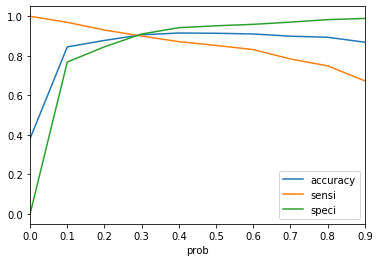

```python
# Let's plot accuracy sensitivity and specificity for various probabilities.
cutoff_df.plot.line(x='prob', y=['accuracy','sensi','speci'])
plt.show()
```

#### from the above plot, optimal point is around 0.3.

```python
y_train_pred_final['final_predicted'] = y_train_pred_final.Conv_Prob.map( lambda x: 1 if x > 0.3 else 0)

y_train_pred_final.head()
```

|  | Converted | Conv_Prob | CustID | predicted | 0.0 | 0.1 | 0.2 | 0.3 | 0.4 | 0.5 | 0.6 | 0.7 | 0.8 | 0.9 | final_predicted |
| --- | --- | --- | --- | --- | --- | --- | --- | --- | --- | --- | --- | --- | --- | --- | --- |
| 0 | 0 | 0.003213 | 1871 | 0 | 1 | 0 | 0 | 0 | 0 | 0 | 0 | 0 | 0 | 0 | 0 |
| 1 | 0 | 0.331771 | 6795 | 0 | 1 | 1 | 1 | 1 | 0 | 0 | 0 | 0 | 0 | 0 | 1 |
| 2 | 0 | 0.003806 | 3516 | 0 | 1 | 0 | 0 | 0 | 0 | 0 | 0 | 0 | 0 | 0 | 0 |
| 3 | 0 | 0.160769 | 8105 | 0 | 1 | 1 | 0 | 0 | 0 | 0 | 0 | 0 | 0 | 0 | 0 |
| 4 | 0 | 0.185115 | 3934 | 0 | 1 | 1 | 0 | 0 | 0 | 0 | 0 | 0 | 0 | 0 | 0 |

```python
# Let's check the overall accuracy.
metrics.accuracy_score(y_train_pred_final.Converted, y_train_pred_final.final_predicted)
```

```
0.9061533704390847
```

```python
confusion2 = metrics.confusion_matrix(y_train_pred_final.Converted, y_train_pred_final.final_predicted )
confusion2
```

```
array([[3642,  360],
       [ 247, 2219]], dtype=int64)
```

```python
TP = confusion2[1,1] # true positive
TN = confusion2[0,0] # true negatives
FP = confusion2[0,1] # false positives
FN = confusion2[1,0] # false negatives
```

```python
# Let's see the sensitivity of our logistic regression model
TP / float(TP+FN)
```

```
0.8998377939983779
```

```python
# Let us calculate specificity
TN / float(TN+FP)
```

```
0.9100449775112444
```

```python
# Calculate false postive rate - predicting churn when customer does not have churned
print(FP/ float(TN+FP))
```

```
0.08995502248875563
```

```python
# Positive predictive value
print (TP / float(TP+FP))
```

```
0.8604110120201629
```

```python
# Negative predictive value
print (TN / float(TN+ FN))
```

```
0.9364875289277449
```

### Making predictions on the test set

```python
#Precision
#TP / TP + FP

confusion[1,1]/(confusion[0,1]+confusion[1,1])
```

```
0.9025619487610248
```

```python
#Recall
#TP / TP + FN

confusion[1,1]/(confusion[1,0]+confusion[1,1])
```

```
0.8714517437145174
```

```python
from sklearn.metrics import precision_score, recall_score
```

```python
precision_score(y_train_pred_final.Converted, y_train_pred_final.predicted)
```

```
0.9025619487610248
```

```python
recall_score(y_train_pred_final.Converted, y_train_pred_final.predicted)
```

```
0.8714517437145174
```

```python
from sklearn.metrics import precision_recall_curve
```

```python
p, r, thresholds = precision_recall_curve(y_train_pred_final.Converted, y_train_pred_final.Conv_Prob)
```

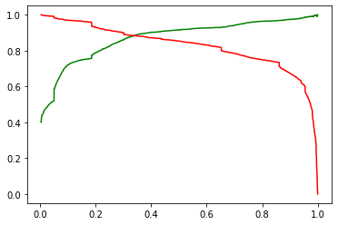

```python
plt.plot(thresholds, p[:-1], "g-")
plt.plot(thresholds, r[:-1], "r-")
plt.show()
```

```python
X_test[['TotalVisits','Total_Time_Spent_on_Website','Page_Views_Per_Visit']]=scaler.transform(X_test[['TotalVisits','Total_Time_Spent_on_Website','Page_Views_Per_Visit']])
```

```python
X_test = X_test[col]
X_test.head()
```

|  | Total_Time_Spent_on_Website | Specialization_Travel and Tourism | Lead_Source_Welingak Website | Lead_Origin_Lead Add Form | What_is_your_current_occupation_OTHERS | Tags_Already a student | Tags_Closed by Horizzon | Tags_Interested in full time MBA | Tags_Interested in other courses | Tags_Not doing further education | Tags_Ringing | Tags_Will revert after reading the email | Tags_switched off | Last_Notable_Activity_OTHERS | Last_Notable_Activity_SMS Sent |
| --- | --- | --- | --- | --- | --- | --- | --- | --- | --- | --- | --- | --- | --- | --- | --- |
| 4269 | 0.964504 | 0 | 0 | 0 | 1 | 0 | 0 | 0 | 0 | 0 | 0 | 0 | 0 | 0 | 1 |
| 2376 | -0.885371 | 0 | 0 | 1 | 0 | 0 | 0 | 0 | 0 | 0 | 0 | 1 | 0 | 0 | 1 |
| 7766 | -0.777416 | 0 | 0 | 0 | 0 | 0 | 0 | 0 | 0 | 0 | 0 | 1 | 0 | 1 | 0 |
| 9199 | -0.885371 | 0 | 0 | 0 | 0 | 1 | 0 | 0 | 0 | 0 | 0 | 0 | 0 | 0 | 0 |
| 4359 | -0.885371 | 0 | 0 | 1 | 0 | 0 | 0 | 0 | 0 | 0 | 0 | 1 | 0 | 0 | 0 |

```python
X_test_sm = sm.add_constant(X_test)
```

```python
y_test_pred = res.predict(X_test_sm)
```

```python
y_test_pred[:10]
```

```
4269    0.686457
2376    0.994292
7766    0.956050
9199    0.002753
4359    0.954783
9186    0.992727
1631    0.969230
8963    0.904985
8007    0.083370
5324    0.985089
dtype: float64
```

```python
# Converting y_pred to a dataframe which is an array
y_pred_1 = pd.DataFrame(y_test_pred)
```

```python
# Converting y_test to dataframe
y_test_df = pd.DataFrame(y_test)
```

```python
y_test_df['LeadID'] = y_test_df.index
y_test_df.head()
```

|  | Converted | LeadID |
| --- | --- | --- |
| 4269 | 1 | 4269 |
| 2376 | 1 | 2376 |
| 7766 | 1 | 7766 |
| 9199 | 0 | 9199 |
| 4359 | 1 | 4359 |

```python
# Removing index for both dataframes to append them side by side
y_pred_1.reset_index(drop=True, inplace=True)
y_test_df.reset_index(drop=True, inplace=True)
```

```python
# Appending y_test_df and y_pred_1
y_pred_final = pd.concat([y_test_df, y_pred_1],axis=1)
```

```python
y_pred_final.head()
```

|  | Converted | LeadID | 0 |
| --- | --- | --- | --- |
| 0 | 1 | 4269 | 0.686457 |
| 1 | 1 | 2376 | 0.994292 |
| 2 | 1 | 7766 | 0.956050 |
| 3 | 0 | 9199 | 0.002753 |
| 4 | 1 | 4359 | 0.954783 |

```python
# Renaming the column
y_pred_final= y_pred_final.rename(columns={ 0 : 'Convert_Prob'})
```

```python
# Rearranging the columns
y_pred_final = y_pred_final.reindex_axis(['LeadID','Converted','Convert_Prob'], axis=1)
```

```python
y_pred_final['final_predicted'] = y_pred_final.Convert_Prob.map(lambda x: 1 if x > 0.3 else 0)
```

```python
y_pred_final.head()
```

|  | LeadID | Converted | Convert_Prob | final_predicted |
| --- | --- | --- | --- | --- |
| 0 | 4269 | 1 | 0.686457 | 1 |
| 1 | 2376 | 1 | 0.994292 | 1 |
| 2 | 7766 | 1 | 0.956050 | 1 |
| 3 | 9199 | 0 | 0.002753 | 0 |
| 4 | 4359 | 1 | 0.954783 | 1 |

```python
# Let's check the overall accuracy.
metrics.accuracy_score(y_pred_final.Converted, y_pred_final.final_predicted)
```

```
0.9105339105339105
```

```python
confusion2 = metrics.confusion_matrix(y_pred_final.Converted, y_pred_final.final_predicted )
confusion2
```

```
array([[1518,  159],
       [  89, 1006]], dtype=int64)
```

```python
TP = confusion2[1,1] # true positive
TN = confusion2[0,0] # true negatives
FP = confusion2[0,1] # false positives
FN = confusion2[1,0] # false negatives
```

```python
# Let's see the sensitivity of our logistic regression model
TP / float(TP+FN)
```

```
0.9187214611872146
```

```python
# Let us calculate specificity
TN / float(TN+FP)
```

```
0.9051878354203936
```